# Data Understanding

Going forward with the anaylisis, the goal in the second step is to have a first perception of the information bring by the data and create hypotheses about them. For being able to do so, we will develop the following points:

## Collect initial data

The dataset was delivered together with the description of the task and is in *csv format*. It contains 1000 observations 1 by row, 30 input variables and 1 out variable. In addition to the dataset, we seek for more information in videos in youtube where we were mainly intended to familiarize with the operation by itself and, hence, indeep more into the variables that we consider that bring more information.

## Describe data

In this point, we will examine the gross properties of the adquire data. Let’s start checking the stucture and size of it. As you can see below, there is 1000 rows and 32 variables of which the first column list all the observations taken, 30 columns the inputvariables and, the last one, the output variables that answer if the person represent a high risk (the credit is rejected) or not (the credit is accepted).

```r
dim(data)
```

```
## [1] 1000   32
```

Now, let’s give a look to the summary and the structe of the data, including their statistical characteristics, for example, minimum, mean, maximum, so on.

Overview of the dataset (1000 observations):

#### Summary

Data Frame Summary

data

**Dimensions**: 1000 x 32  
**Duplicates**: 0

| **No** | **Variable** | **Stats / Values** | **Freqs (% of Valid)** | **Graph** | **Missing** |
| --- | --- | --- | --- | --- | --- |
| 1 | OBS# [integer] | Mean (sd) : 500.5 (288.8) min < med < max: 1 < 500.5 < 1000 IQR (CV) : 499.5 (0.6) | 1000 distinct values (Integer sequence) |  | 0 (0%) |
| 2 | CHK_ACCT [integer] | Mean (sd) : 1.6 (1.3) min < med < max: 0 < 1 < 3 IQR (CV) : 3 (0.8) | 0 : 274 ( 27.4% ) 1 : 269 ( 26.9% ) 2 : 63 ( 6.3% ) 3 : 394 ( 39.4% ) |  | 0 (0%) |
| 3 | DURATION [integer] | Mean (sd) : 20.9 (12.1) min < med < max: 4 < 18 < 72 IQR (CV) : 12 (0.6) | 33 distinct values |  | 0 (0%) |
| 4 | HISTORY [integer] | Mean (sd) : 2.5 (1.1) min < med < max: 0 < 2 < 4 IQR (CV) : 2 (0.4) | 0 : 40 ( 4.0% ) 1 : 49 ( 4.9% ) 2 : 530 ( 53.0% ) 3 : 88 ( 8.8% ) 4 : 293 ( 29.3% ) |  | 0 (0%) |
| 5 | NEW_CAR [integer] | Min : 0 Mean : 0.2 Max : 1 | 0 : 766 ( 76.6% ) 1 : 234 ( 23.4% ) |  | 0 (0%) |
| 6 | USED_CAR [integer] | Min : 0 Mean : 0.1 Max : 1 | 0 : 897 ( 89.7% ) 1 : 103 ( 10.3% ) |  | 0 (0%) |
| 7 | FURNITURE [integer] | Min : 0 Mean : 0.2 Max : 1 | 0 : 819 ( 81.9% ) 1 : 181 ( 18.1% ) |  | 0 (0%) |
| 8 | RADIO.TV [integer] | Min : 0 Mean : 0.3 Max : 1 | 0 : 720 ( 72.0% ) 1 : 280 ( 28.0% ) |  | 0 (0%) |
| 9 | EDUCATION [integer] | Mean (sd) : 0 (0.2) min < med < max: -1 < 0 < 1 IQR (CV) : 0 (4.6) | -1 : 1 ( 0.1% ) 0 : 950 ( 95.0% ) 1 : 49 ( 4.9% ) |  | 0 (0%) |
| 10 | RETRAINING [integer] | Min : 0 Mean : 0.1 Max : 1 | 0 : 903 ( 90.3% ) 1 : 97 ( 9.7% ) |  | 0 (0%) |
| 11 | AMOUNT [integer] | Mean (sd) : 3271.3 (2822.7) min < med < max: 250 < 2319.5 < 18424 IQR (CV) : 2606.8 (0.9) | 921 distinct values |  | 0 (0%) |
| 12 | SAV_ACCT [integer] | Mean (sd) : 1.1 (1.6) min < med < max: 0 < 0 < 4 IQR (CV) : 2 (1.4) | 0 : 603 ( 60.3% ) 1 : 103 ( 10.3% ) 2 : 63 ( 6.3% ) 3 : 48 ( 4.8% ) 4 : 183 ( 18.3% ) |  | 0 (0%) |
| 13 | EMPLOYMENT [integer] | Mean (sd) : 2.4 (1.2) min < med < max: 0 < 2 < 4 IQR (CV) : 2 (0.5) | 0 : 62 ( 6.2% ) 1 : 172 ( 17.2% ) 2 : 339 ( 33.9% ) 3 : 174 ( 17.4% ) 4 : 253 ( 25.3% ) |  | 0 (0%) |
| 14 | INSTALL_RATE [integer] | Mean (sd) : 3 (1.1) min < med < max: 1 < 3 < 4 IQR (CV) : 2 (0.4) | 1 : 136 ( 13.6% ) 2 : 231 ( 23.1% ) 3 : 157 ( 15.7% ) 4 : 476 ( 47.6% ) |  | 0 (0%) |
| 15 | MALE_DIV [integer] | Min : 0 Mean : 0 Max : 1 | 0 : 950 ( 95.0% ) 1 : 50 ( 5.0% ) |  | 0 (0%) |
| 16 | MALE_SINGLE [integer] | Min : 0 Mean : 0.5 Max : 1 | 0 : 452 ( 45.2% ) 1 : 548 ( 54.8% ) |  | 0 (0%) |
| 17 | MALE_MAR_WID [integer] | Min : 0 Mean : 0.1 Max : 1 | 0 : 908 ( 90.8% ) 1 : 92 ( 9.2% ) |  | 0 (0%) |
| 18 | CO-APPLICANT [integer] | Min : 0 Mean : 0 Max : 1 | 0 : 959 ( 95.9% ) 1 : 41 ( 4.1% ) |  | 0 (0%) |
| 19 | GUARANTOR [integer] | Mean (sd) : 0.1 (0.2) min < med < max: 0 < 0 < 2 IQR (CV) : 0 (4.3) | 0 : 948 ( 94.8% ) 1 : 51 ( 5.1% ) 2 : 1 ( 0.1% ) |  | 0 (0%) |
| 20 | PRESENT_RESIDENT [integer] | Mean (sd) : 2.8 (1.1) min < med < max: 1 < 3 < 4 IQR (CV) : 2 (0.4) | 1 : 130 ( 13.0% ) 2 : 308 ( 30.8% ) 3 : 149 ( 14.9% ) 4 : 413 ( 41.3% ) |  | 0 (0%) |
| 21 | REAL_ESTATE [integer] | Min : 0 Mean : 0.3 Max : 1 | 0 : 718 ( 71.8% ) 1 : 282 ( 28.2% ) |  | 0 (0%) |
| 22 | PROP_UNKN_NONE [integer] | Min : 0 Mean : 0.2 Max : 1 | 0 : 846 ( 84.6% ) 1 : 154 ( 15.4% ) |  | 0 (0%) |
| 23 | AGE [integer] | Mean (sd) : 35.6 (11.7) min < med < max: 19 < 33 < 125 IQR (CV) : 15 (0.3) | 54 distinct values |  | 0 (0%) |
| 24 | OTHER_INSTALL [integer] | Min : 0 Mean : 0.2 Max : 1 | 0 : 814 ( 81.4% ) 1 : 186 ( 18.6% ) |  | 0 (0%) |
| 25 | RENT [integer] | Min : 0 Mean : 0.2 Max : 1 | 0 : 821 ( 82.1% ) 1 : 179 ( 17.9% ) |  | 0 (0%) |
| 26 | OWN_RES [integer] | Min : 0 Mean : 0.7 Max : 1 | 0 : 287 ( 28.7% ) 1 : 713 ( 71.3% ) |  | 0 (0%) |
| 27 | NUM_CREDITS [integer] | Mean (sd) : 1.4 (0.6) min < med < max: 1 < 1 < 4 IQR (CV) : 1 (0.4) | 1 : 633 ( 63.3% ) 2 : 333 ( 33.3% ) 3 : 28 ( 2.8% ) 4 : 6 ( 0.6% ) |  | 0 (0%) |
| 28 | JOB [integer] | Mean (sd) : 1.9 (0.7) min < med < max: 0 < 2 < 3 IQR (CV) : 0 (0.3) | 0 : 22 ( 2.2% ) 1 : 200 ( 20.0% ) 2 : 630 ( 63.0% ) 3 : 148 ( 14.8% ) |  | 0 (0%) |
| 29 | NUM_DEPENDENTS [integer] | Min : 1 Mean : 1.2 Max : 2 | 1 : 845 ( 84.5% ) 2 : 155 ( 15.5% ) |  | 0 (0%) |
| 30 | TELEPHONE [integer] | Min : 0 Mean : 0.4 Max : 1 | 0 : 596 ( 59.6% ) 1 : 404 ( 40.4% ) |  | 0 (0%) |
| 31 | FOREIGN [integer] | Min : 0 Mean : 0 Max : 1 | 0 : 963 ( 96.3% ) 1 : 37 ( 3.7% ) |  | 0 (0%) |
| 32 | RESPONSE [integer] | Min : 0 Mean : 0.7 Max : 1 | 0 : 300 ( 30.0% ) 1 : 700 ( 70.0% ) |  | 0 (0%) |

Generated by summarytools 0.9.6 ([R](https://www.r-project.org/) version 4.0.0)  
2020-11-23

#### Output variable: yes / no

[figure not shown]

#### Description by output variable

```
##
##  Descriptive statistics by group
## group: 0
##                  vars   n    mean      sd median trimmed     mad min   max
## OBS#                1 300  515.76  281.03  542.0  518.66  349.15   2   999
## CHK_ACCT            2 300    0.90    1.05    1.0    0.75    1.48   0     3
## DURATION            3 300   24.86   13.28   24.0   23.59   17.79   6    72
## HISTORY             4 300    2.17    1.08    2.0    2.19    0.00   0     4
## NEW_CAR             5 300    0.30    0.46    0.0    0.25    0.00   0     1
## USED_CAR            6 300    0.06    0.23    0.0    0.00    0.00   0     1
## FURNITURE           7 300    0.19    0.40    0.0    0.12    0.00   0     1
## RADIO.TV            8 300    0.21    0.41    0.0    0.13    0.00   0     1
## EDUCATION           9 300    0.07    0.26    0.0    0.00    0.00   0     1
## RETRAINING         10 300    0.11    0.32    0.0    0.02    0.00   0     1
## AMOUNT             11 300 3938.13 3535.82 2574.5 3291.18 2092.69 433 18424
## SAV_ACCT           12 300    0.67    1.30    0.0    0.34    0.00   0     4
## EMPLOYMENT         13 300    2.17    1.22    2.0    2.18    1.48   0     4
## INSTALL_RATE       14 300    3.10    1.09    4.0    3.25    0.00   1     4
## MALE_DIV           15 300    0.07    0.25    0.0    0.00    0.00   0     1
## MALE_SINGLE        16 300    0.49    0.50    0.0    0.48    0.00   0     1
## MALE_MAR_WID       17 300    0.08    0.28    0.0    0.00    0.00   0     1
## CO-APPLICANT       18 300    0.06    0.24    0.0    0.00    0.00   0     1
## GUARANTOR          19 300    0.03    0.18    0.0    0.00    0.00   0     1
## PRESENT_RESIDENT   20 300    2.85    1.09    3.0    2.94    1.48   1     4
## REAL_ESTATE        21 300    0.20    0.40    0.0    0.12    0.00   0     1
## PROP_UNKN_NONE     22 300    0.22    0.42    0.0    0.15    0.00   0     1
## AGE                23 300   33.96   11.22   31.0   32.38    8.90  19    74
## OTHER_INSTALL      24 300    0.25    0.44    0.0    0.19    0.00   0     1
## RENT               25 300    0.23    0.42    0.0    0.17    0.00   0     1
## OWN_RES            26 300    0.62    0.49    1.0    0.65    0.00   0     1
## NUM_CREDITS        27 300    1.37    0.56    1.0    1.29    0.00   1     4
## JOB                28 300    1.94    0.67    2.0    1.95    0.00   0     3
## NUM_DEPENDENTS     29 300    1.15    0.36    1.0    1.07    0.00   1     2
## TELEPHONE          30 300    0.38    0.49    0.0    0.35    0.00   0     1
## FOREIGN            31 300    0.01    0.11    0.0    0.00    0.00   0     1
## RESPONSE           32 300    0.00    0.00    0.0    0.00    0.00   0     0
##                  range  skew kurtosis     se
## OBS#               997 -0.08    -1.13  16.23
## CHK_ACCT             3  0.99    -0.27   0.06
## DURATION            66  0.83     0.03   0.77
```

[output cut: 82 more lines]

```
## CO-APPLICANT         1  5.23    25.39  0.01
## GUARANTOR            2  3.93    14.88  0.01
## PRESENT_RESIDENT     3 -0.28    -1.38  0.04
## REAL_ESTATE          1  0.78    -1.39  0.02
## PROP_UNKN_NONE       1  2.27     3.17  0.01
## AGE                106  1.43     4.51  0.45
## OTHER_INSTALL        1  1.88     1.54  0.01
## RENT                 1  1.89     1.59  0.01
## OWN_RES              1 -1.17    -0.63  0.02
## NUM_CREDITS          3  1.20     1.30  0.02
## JOB                  3 -0.37     0.50  0.02
## NUM_DEPENDENTS       1  1.89     1.59  0.01
## TELEPHONE            1  0.34    -1.89  0.02
## FOREIGN              1  4.26    16.21  0.01
## RESPONSE             0   NaN      NaN  0.00
```

As we see in the table show earlier, all the values are integers and there is not any missing value. In addition, we can see some inconsistencies of the variables with the initial description, that we will explain in following.

[output not shown]

Then, for the 3 inconsistencies found before, We have established the following hypothesis and solutions.

- EDUCATION: there was an error in the registration of the information and the -1 must be replaced by 1.
- PRESENT_RESIDENT: Again, there was an error in the registration of the information and the register was made in years instead of the category.
- AGE: Here it is clear that we have some outliers, we should limit the age to 75.

It is also important to mention that the output variables show in 70% that the credit is accepted and in 30% rejected, which can later bias the prediction.

## Explore data

In this section, we will go deeper into the data and look for patterns or relationships between variables. For being able to do that we will develop an histogram to check the distribution of our data for each variable.

Overview of the dataset without any modification. Note: a detailed description of each variable can be found in the appendix

#### Histogram

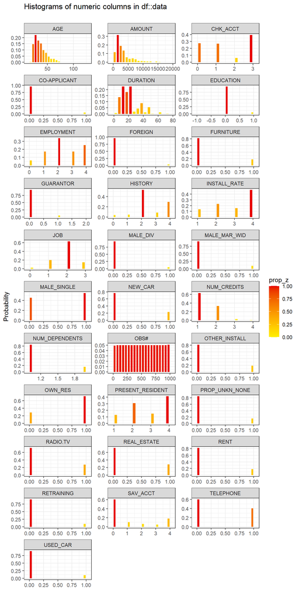

#### Histogram by answer

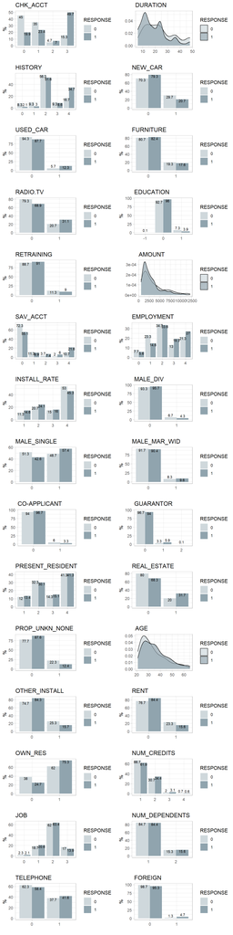

Regarding the last charts, we have the following observations:

- We can see that the numerical variable have a normal distribution asymmetric to the right (Skewed (Non-Normal) Right), possible because we have a more significant lower bound.
- It is very difficult to indentify patterns in the data.
- In the second one, histogram by response variable, we are able to see the proportion within the positives and negatives answers applications.

Consider that the graphs are an overview of the dataset without any modification.

#### Boxplot

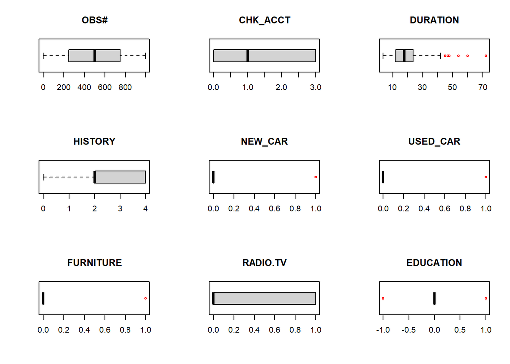

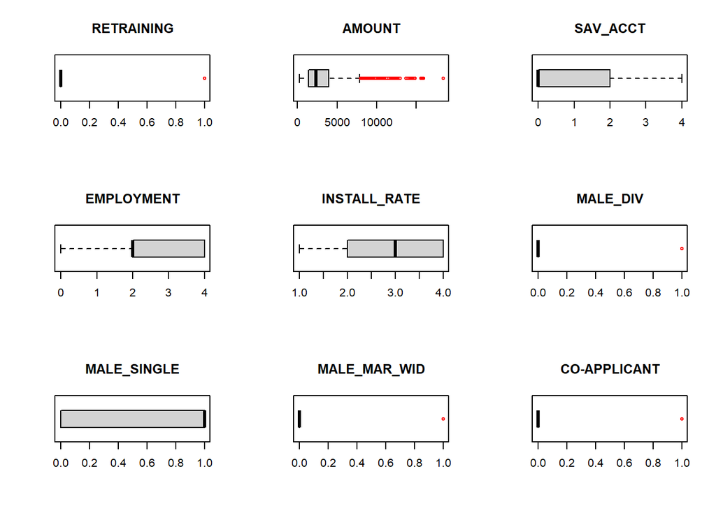

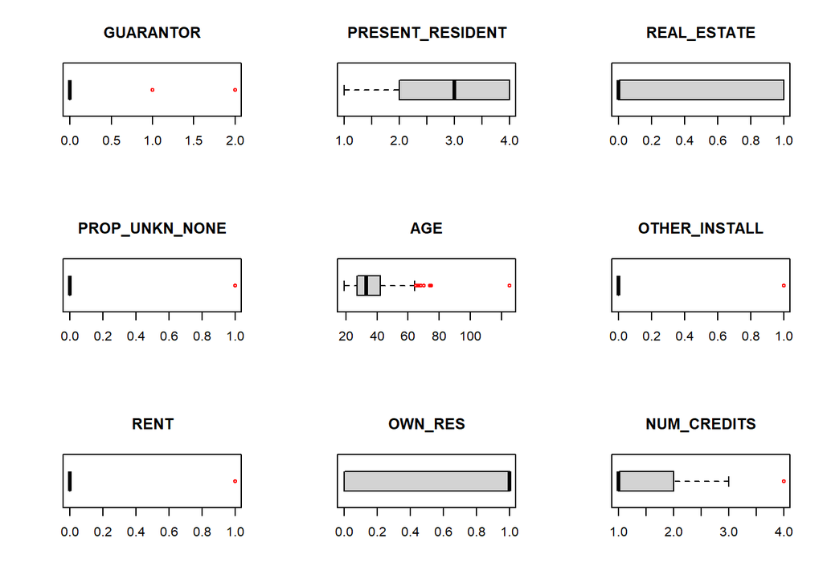

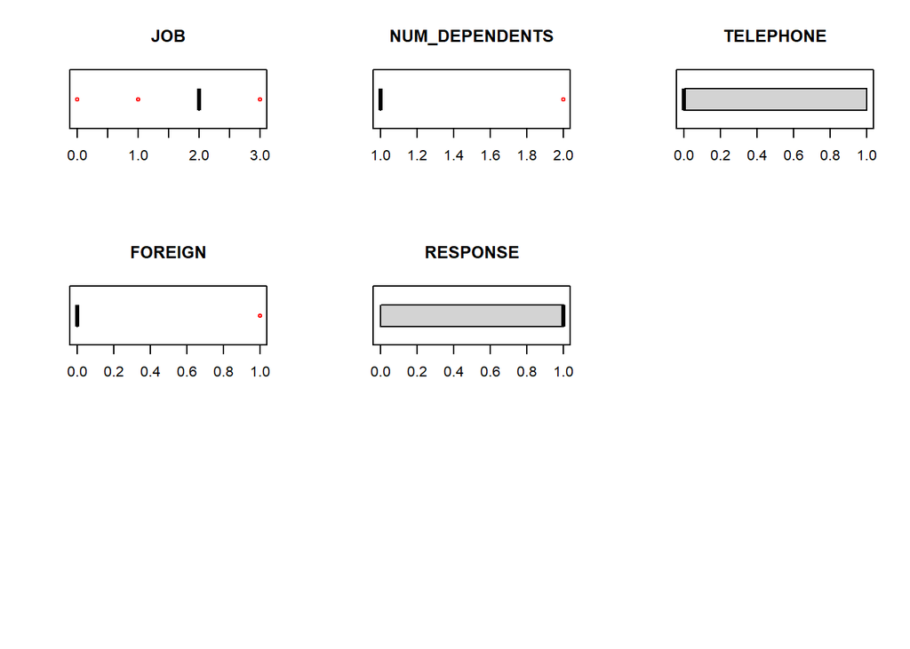

#### Boxplot by output

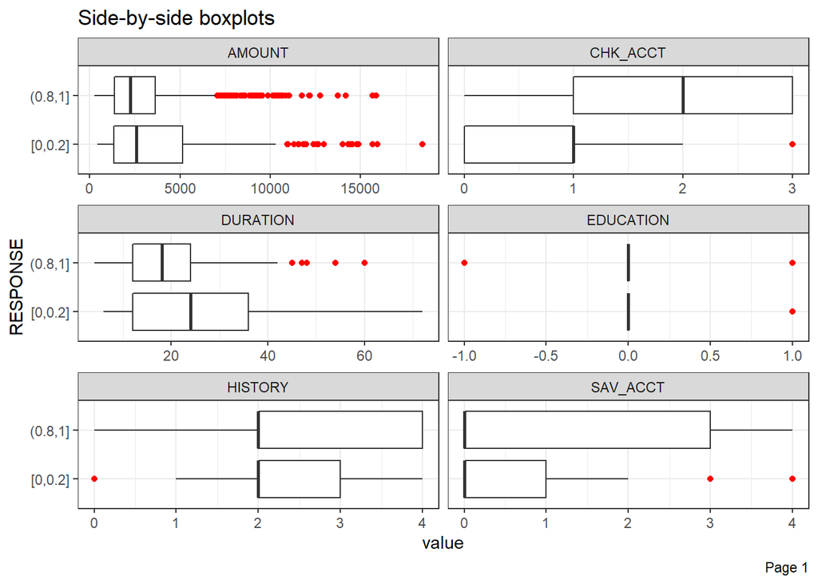

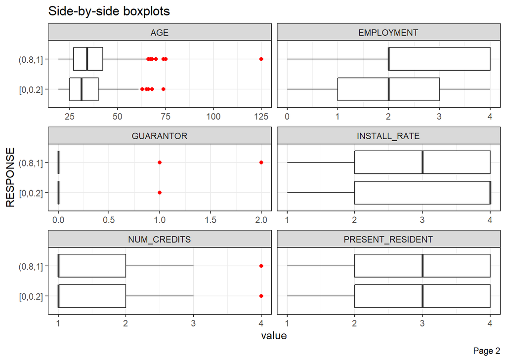

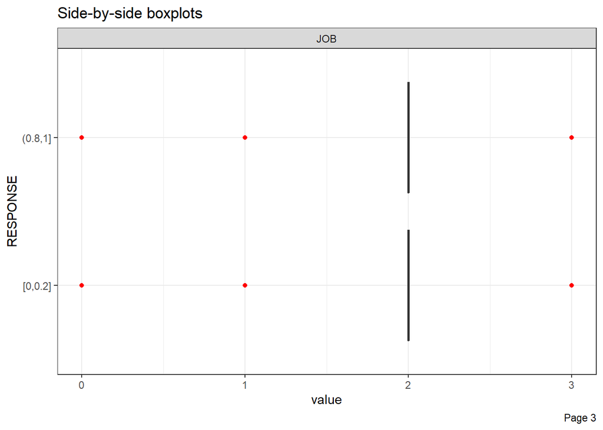

In the following table, you will find our principal observations.

[output not shown]

Additionally, we could identify some outliers, show as red dots and, as you can see in the second chart, the input variables cluster by the outvariable variable show that there are some features that bring more information than others.

**key definitions:**

1. *Real property includes the physical property (physical land, structures and resources attached to it) of the real estate, but it expands its definition to include other types of ownerships as rights. Meaning that we can have properties without real state (PROP_UNKN_NONE =0 & REAL_ESTATE=0)*
2. *For the RENT and OWN_RES variable, we can 3 cases 1-0 , 0-1 and 0-0 because there exist the possible that the person who apply for the loan do not owns the residence and either is in charge of any rents.*

Now, we will give a look to the importance of each variable and we will evaluate 2 point:

- Multicollinearity
- Correlation

#### Multicollinearity

```
##           `OBS#`         CHK_ACCT         DURATION          HISTORY
##         1.015618         1.172296         1.986243         1.383615
##          NEW_CAR         USED_CAR        FURNITURE         RADIO.TV
##         3.926295         2.657217         3.495355         4.345172
##        EDUCATION       RETRAINING           AMOUNT         SAV_ACCT
##         1.765973         2.504382         2.378371         1.108851
##       EMPLOYMENT     INSTALL_RATE         MALE_DIV      MALE_SINGLE
##         1.229366         1.349092         1.169215         1.569347
##     MALE_MAR_WID   `CO-APPLICANT`        GUARANTOR PRESENT_RESIDENT
##         1.244157         1.052029         1.086770         1.288490
##      REAL_ESTATE   PROP_UNKN_NONE              AGE    OTHER_INSTALL
##         1.246643         2.777984         1.324381         1.059513
##             RENT          OWN_RES      NUM_CREDITS              JOB
##         4.710092         5.989103         1.328288         1.363509
##   NUM_DEPENDENTS        TELEPHONE          FOREIGN
##         1.169308         1.287962         1.090643
```

#### Correlation

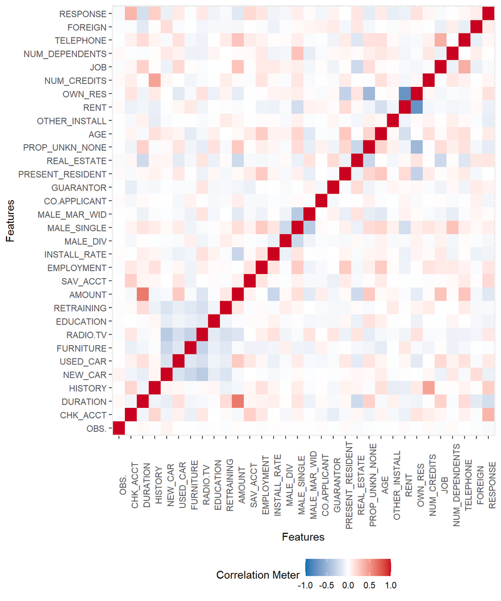

Our observations about the chart shown before are in the following table:

| Anylisis | Observation |
| --- | --- |
| Multicollinearity | There is one variable which VIF is higher from 5: OWN_RES |
| Correlation | This correlation graph proof what was found in the Multicollinearity analysis. |

In general, the VIF is no high enough to eliminate the variable.

## Verify data quality

For being able to do so, we stablish 3 questions that we will address during the resolution of this step. They are the following:

1. Is the data complete (does it cover all the cases required)?
2. Is it correct or does it contain errors?
3. Are there missing values in the data? If so how are they represented?

#### Description dataset

```
##   rows columns discrete_columns continuous_columns all_missing_columns
## 1 1000      31                0                 31                   0
##   total_missing_values complete_rows total_observations memory_usage
## 1                    0          1000              31000       131056
```

[figure not shown]

#### Missing Values

```
## [1] 0
```

```
## [1] 1
```

[figure not shown]

```
## # A tibble: 1 x 4
##   type      cnt  pcnt col_name
##   <chr>   <int> <dbl> <named list>
## 1 integer    31   100 <chr [31]>
```

Below you will find the answer of the 3 questions:

[output not shown]

In addittion, we are going to anaylise if the agroupation mention in the boxplot for each variable is possible, for being able to do so, we are going to apply the **Chi-Square Test** for measure independence between them. Next, we are going to explain the steps taking for each analysis:

**1) Variables: REAL_ESTATE and PROP_UNKN_NONE**

First, we stablish the hypotheses:

$$H_ {0}: \ The \ REAL \ ESTATE \ and \ PROP \ UNKN \ NONE \ are \ independent \ variables.$$

against the bilateral alternative:

$$H_ {1}: \ They \ are \ not \ independent.$$

For the $X^2$ test to be valid, the following conditions must be accomplish:

1. The sampling method is random
2. Categorical variables
3. Size: All levels have more than 5 expected events.

*Assuptions*: Significance level of **0.05** *Clarifications*: The P-value is the probability that a chi-square statistic having X degrees of freedom is more extreme than $X^2$.

Finally, we are going to accept or reject the hypotheses checking the P-value. If the P-value is less than the significance level stablish earlier, hence, we cannot accept the null hypothesis. Thus, we conclude that there is a relationship between the variables.

**2) RENT and OWN_RES**

First, we stablish the hypotheses:

$$H_ {0}: \ The \ RENT \ and \ OWN \ RES \ are \ independent \ variables.$$

against the bilateral alternative:

$$H_ {1}: \ They \ are \ not \ independent.$$

For the $X^2$ test to be valid, the following conditions must be accomplish:

1. The sampling method is random
2. Categorical variables
3. Size: All levels have more than 5 expected events.

*Assuptions*: Significance level of **0.05** *Clarifications*: The P-value is the probability that a chi-square statistic having X degrees of freedom is more extreme than $X^2$.

Finally, we are going to accept or reject the hypotheses checking the P-value. If the P-value is less than the significance level stablish earlier, hence, we cannot accept the null hypothesis. Thus, we conclude that there is a relationship between the variables.